# WhtDisID_Github

doris dai

10/9/2019

# Project Overview

Secured votes from 54% of White Americans——comprising 88% of his voter base——Trump’s 2016 presidential win has created a (mis)perception: Trump represents the majority of White Americans, and his statments represents the viewpoints of the majority of White Americans. This (mis)perceived representativeness of Trump linked White Americans as a group to discriminatory ideologies, via Trump’s sexist, racist, and xenophobic statements regarding marginalized group during and after his campaign. This public image of the White racial group arguably creates psychological tension for liberal-leaning Whites, whose personal ideologies tend to be pro-egalitarian and antithetical to the discriminatory ideologies (e.g., racism, xenophobia, White supremacy and sexism) associated with their racial ingroup. In this project, we explored how liberal-leaning Whites Americans contend with the current public image of their racial ingroup through negotiating their racial identity. We conceptualize this tension as a form of *group-image threat* (i.e., a threat to one’s self-concept that arises when faced with negative attributes of one’s ingroup), and hypothesized that this threat leads liberal-leaning (but not conservative-leaning) Whites to *disidentify* from their racial ingroup (**H1**), and such racial disidentification will be coupled with increased *intentions to advocate for racial equality* (**H2**).

To test these two hypotheses, we conducted 3 studies, with a total sample of 2,481 White Americans via Amazon Mechanical Turk across a one-year span (from 5/23/2018 to 4/17/2019). Studies 1a, 1b and 2 tested **H1**, and study 2 tested **H2**.

Below you can find the results. Refer to *WhtDisId_analysis.R* for codes used, which can be used for replication along with the redacted datasets.

## Variables and Measures

| No. | VariableNames | ShortdiscriptionofMeasurement |
| --- | --- | --- |
| 1 | Political orientation | Participants’ personal political beliefs (1 = extremely conservative to 8 = extremely liberal) |
| 2 | White disidentification | Participants’ tendency to distance themselves from the White racial group (1 = Strongly disagree to 7 = Strongly agree) |
| 3 | Trump’s perceived representativeness | Agreement with the idea that Trump’s comments represent viewpoints of the White racial group (1 = Strongly disagree to 7 = Strongly agree) |
| 4 | Liberal group identification | Participants’ tendency to view belonging to the liberal group as central to self-concepts (1 = Strongly disagree to 7 = Strongly agree) |
| 5 | Individual Advocacy | The likelihood that participants would put in personal effort to push for racial equality (1 = Strongly disagree to 7 = Strongly agree) |
| 6 | Policy Support | Participants’ support for policies designed to help racial minorities (1 = Strongly disagree to 7 = Strongly agree) |

# Study 1a

## condition moderates the relation between political orientation and White disidentification (MLR Model Testing)

### Main moderation MLR models

Control Condition as the Reference Level (Study 1a)

|  | Estimate | Std. Error | t value | Pr(>\|t\|) |
| --- | --- | --- | --- | --- |
| (Intercept) | 3.4455124 | 0.0920161 | 37.4446760 | 0.0000000 |
| LibCon_centered | 0.2517122 | 0.0452206 | 5.5663185 | 0.0000000 |
| condition_controlActual threat | 0.0787778 | 0.1285071 | 0.6130229 | 0.5401571 |
| condition_controlHigh threat | 0.3104342 | 0.1296865 | 2.3937279 | 0.0170684 |
| LibCon_centered:condition_controlActual threat | -0.0020036 | 0.0611369 | -0.0327725 | 0.9738699 |
| LibCon_centered:condition_controlHigh threat | 0.1753765 | 0.0616659 | 2.8439779 | 0.0046493 |

Actual Threat Condition as the Reference Level (Study 1a)

|  | Estimate | Std. Error | t value | Pr(>\|t\|) |
| --- | --- | --- | --- | --- |
| (Intercept) | 3.5242902 | 0.0897057 | 39.2872347 | 0.0000000 |
| LibCon_centered | 0.2497086 | 0.0411439 | 6.0691590 | 0.0000000 |
| condition_actualControl | -0.0787778 | 0.1285071 | -0.6130229 | 0.5401571 |
| condition_actualHigh threat | 0.2316564 | 0.1280576 | 1.8090015 | 0.0710882 |
| LibCon_centered:condition_actualControl | 0.0020036 | 0.0611369 | 0.0327725 | 0.9738699 |
| LibCon_centered:condition_actualHigh threat | 0.1773801 | 0.0587418 | 3.0196569 | 0.0026680 |

Simple slopes for political orientation by condition

```
##  condition_control LibCon_centered.trend     SE  df lower.CL upper.CL
##  Control                           0.252 0.0452 471    0.163    0.341
##  Actual threat                     0.250 0.0411 471    0.169    0.331
##  High threat                       0.427 0.0419 471    0.345    0.509
##
## Confidence level used: 0.95
```

### Relatively liberal Whites *vs.* relatively conservative Whites

Control Condition as the Reference Level among Relatively Liberal Participants (Study 1a)

|  | Estimate | Std. Error | t value | Pr(>\|t\|) |
| --- | --- | --- | --- | --- |
| (Intercept) | 3.9826859 | 0.1387803 | 28.6977725 | 0.0000000 |
| LibCon_above | 0.2517122 | 0.0452206 | 5.5663185 | 0.0000000 |
| condition_controlActual threat | 0.0745019 | 0.1870330 | 0.3983359 | 0.6905631 |
| condition_controlHigh threat | 0.6847013 | 0.1853458 | 3.6941832 | 0.0002465 |
| LibCon_above:condition_controlActual threat | -0.0020036 | 0.0611369 | -0.0327725 | 0.9738699 |
| LibCon_above:condition_controlHigh threat | 0.1753765 | 0.0616659 | 2.8439779 | 0.0046493 |

Control Condition as the Reference Level among Relatively Conservative Participants (Study 1a)

|  | Estimate | Std. Error | t value | Pr(>\|t\|) |
| --- | --- | --- | --- | --- |
| (Intercept) | 2.9083389 | 0.1276718 | 22.7798047 | 0.0000000 |
| LibCon_below | 0.2517122 | 0.0452206 | 5.5663185 | 0.0000000 |
| condition_controlActual threat | 0.0830537 | 0.1791427 | 0.4636172 | 0.6431362 |
| condition_controlHigh threat | -0.0638330 | 0.1841770 | -0.3465850 | 0.7290579 |
| LibCon_below:condition_controlActual threat | -0.0020036 | 0.0611369 | -0.0327725 | 0.9738699 |
| LibCon_below:condition_controlHigh threat | 0.1753765 | 0.0616659 | 2.8439779 | 0.0046493 |

Actual Condition as the Reference Level among Relatively Liberal Participants (Study 1a)

|  | Estimate | Std. Error | t value | Pr(>\|t\|) |
| --- | --- | --- | --- | --- |
| (Intercept) | 4.0571878 | 0.1253849 | 32.3578752 | 0.0000000 |
| LibCon_above | 0.2497086 | 0.0411439 | 6.0691590 | 0.0000000 |
| condition_actualControl | -0.0745019 | 0.1870330 | -0.3983359 | 0.6905631 |
| condition_actualHigh threat | 0.6101994 | 0.1755405 | 3.4761181 | 0.0005558 |
| LibCon_above:condition_actualControl | 0.0020036 | 0.0611369 | 0.0327725 | 0.9738699 |
| LibCon_above:condition_actualHigh threat | 0.1773801 | 0.0587418 | 3.0196569 | 0.0026680 |

Actual Condition as the Reference Level among Relatively Conservative Participants (Study 1a)

|  | Estimate | Std. Error | t value | Pr(>\|t\|) |
| --- | --- | --- | --- | --- |
| (Intercept) | 2.9913925 | 0.1256663 | 23.8042480 | 0.0000000 |
| LibCon_below | 0.2497086 | 0.0411439 | 6.0691590 | 0.0000000 |
| condition_actualControl | -0.0830537 | 0.1791427 | -0.4636172 | 0.6431362 |
| condition_actualHigh threat | -0.1468866 | 0.1827925 | -0.8035703 | 0.4220505 |
| LibCon_below:condition_actualControl | 0.0020036 | 0.0611369 | 0.0327725 | 0.9738699 |
| LibCon_below:condition_actualHigh threat | 0.1773801 | 0.0587418 | 3.0196569 | 0.0026680 |

## Plot of Political Orientaion Interacting with Condition on White Disidentification

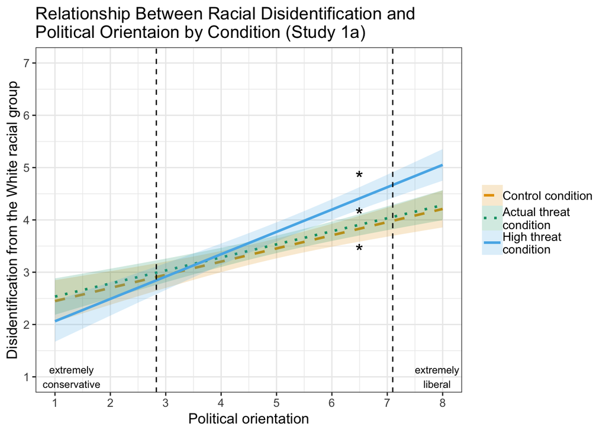

# Study 1b

## Replication of Study 1a (MLR Model Testing)

### Main moderation MLR testing

```
##
## Call:
## lm(formula = WhtDis_comp ~ LibCon_centered + condition_actual +
##     LibCon_centered * condition_actual, data = study1b_relevel)
##
## Residuals:
##     Min      1Q  Median      3Q     Max
## -3.6460 -0.6738 -0.0806  0.8312  3.0308
##
## Coefficients:
##                                             Estimate Std. Error t value
## (Intercept)                                  4.16754    0.05027  82.904
## LibCon_centered                              0.54413    0.02269  23.985
## condition_actualHigh threat                 -1.02075    0.06962 -14.662
## LibCon_centered:condition_actualHigh threat -0.27923    0.03115  -8.963
##                                             Pr(>|t|)
## (Intercept)                                   <2e-16 ***
## LibCon_centered                               <2e-16 ***
## condition_actualHigh threat                   <2e-16 ***
## LibCon_centered:condition_actualHigh threat   <2e-16 ***
## ---
## Signif. codes:  0 '***' 0.001 '**' 0.01 '*' 0.05 '.' 0.1 ' ' 1
##
## Residual standard error: 1.102 on 1001 degrees of freedom
## Multiple R-squared:  0.4862, Adjusted R-squared:  0.4846
## F-statistic: 315.7 on 3 and 1001 DF,  p-value: < 2.2e-16
```

Actual Condition as the Reference Level (Study 1b)

|  | Estimate | Std. Error | t value | Pr(>\|t\|) |
| --- | --- | --- | --- | --- |
| (Intercept) | 4.1675430 | 0.0502692 | 82.904450 | 0 |
| LibCon_centered | 0.5441333 | 0.0226865 | 23.984860 | 0 |
| condition_actualHigh threat | -1.0207519 | 0.0696176 | -14.662259 | 0 |
| LibCon_centered:condition_actualHigh threat | -0.2792252 | 0.0311533 | -8.962928 | 0 |

Simple slopes for political orientation by condition

```
##  condition_actual LibCon_centered.trend     SE   df lower.CL upper.CL
##  Actual threat                    0.544 0.0227 1001    0.500    0.589
##  High threat                      0.265 0.0214 1001    0.223    0.307
##
## Confidence level used: 0.95
```

### Relatively liberal Whites *vs.* relatively conservative Whites

Actual Condition as the Reference Level among Relatively Liberal Participants (Study 1b)

|  | Estimate | Std. Error | t value | Pr(>\|t\|) |
| --- | --- | --- | --- | --- |
| (Intercept) | 5.3852347 | 0.0713031 | 75.525942 | 0 |
| LibCon_above | 0.5441333 | 0.0226865 | 23.984860 | 0 |
| condition_actualHigh threat | -1.6456177 | 0.0985050 | -16.705939 | 0 |
| LibCon_above:condition_actualHigh threat | -0.2792252 | 0.0311533 | -8.962928 | 0 |

Actual Condition as the Reference Level among Relatively Conservative Participants (Study 1b)

|  | Estimate | Std. Error | t value | Pr(>\|t\|) |
| --- | --- | --- | --- | --- |
| (Intercept) | 2.9498513 | 0.0715882 | 41.205806 | 0.00e+00 |
| LibCon_below | 0.5441333 | 0.0226865 | 23.984860 | 0.00e+00 |
| condition_actualHigh threat | -0.3958862 | 0.0985436 | -4.017370 | 6.33e-05 |
| LibCon_below:condition_actualHigh threat | -0.2792252 | 0.0311533 | -8.962928 | 0.00e+00 |

## Plot of Political Orientaion Interacting with Condition on White Disidentification

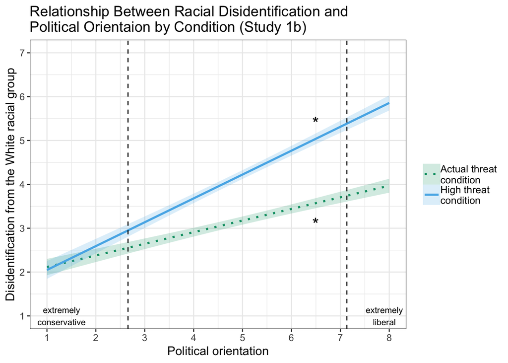

## Liberal Identification as Covariate (Alternative Explanation Testing)

Effect of Political Orientation and Condition Above and Beyond Liberal Identification

|  | Estimate | Std. Error | t value | Pr(>\|t\|) |
| --- | --- | --- | --- | --- |
| (Intercept) | 4.6919274 | 0.1403221 | 33.436848 | 0.0e+00 |
| LibId_comp | -0.1325454 | 0.0333599 | -3.973195 | 7.6e-05 |
| LibCon_centered | 0.6361295 | 0.0322957 | 19.697018 | 0.0e+00 |
| condition_actualHigh threat | -1.0055184 | 0.0694579 | -14.476663 | 0.0e+00 |
| LibCon_centered:condition_actualHigh threat | -0.2884877 | 0.0310338 | -9.295906 | 0.0e+00 |

# Study 2

## Replication of Study 1a (MLR Model Testing)

Control Condition as the Reference Level (Study 2)

|  | Estimate | Std. Error | t value | Pr(>\|t\|) |
| --- | --- | --- | --- | --- |
| (Intercept) | 3.2571530 | 0.0632175 | 51.5229373 | 0.0000000 |
| LibCon_centered | 0.3533918 | 0.0305119 | 11.5820848 | 0.0000000 |
| condition_controlActual threat | -0.0077635 | 0.0923345 | -0.0840798 | 0.9330130 |
| condition_controlHigh threat | 0.2721231 | 0.0907522 | 2.9985293 | 0.0027927 |
| LibCon_centered:condition_controlActual threat | -0.0771810 | 0.0440613 | -1.7516751 | 0.0801937 |
| LibCon_centered:condition_controlHigh threat | 0.0378340 | 0.0426048 | 0.8880221 | 0.3747825 |

Actual Threat Condition as the Reference Level (Study 2)

|  | Estimate | Std. Error | t value | Pr(>\|t\|) |
| --- | --- | --- | --- | --- |
| (Intercept) | 3.2493895 | 0.0672993 | 48.2826702 | 0.0000000 |
| LibCon_centered | 0.2762108 | 0.0317871 | 8.6894134 | 0.0000000 |
| condition_actualControl | 0.0077635 | 0.0923345 | 0.0840798 | 0.9330130 |
| condition_actualHigh threat | 0.2798865 | 0.0936413 | 2.9889214 | 0.0028810 |
| LibCon_centered:condition_actualControl | 0.0771810 | 0.0440613 | 1.7516751 | 0.0801937 |
| LibCon_centered:condition_actualHigh threat | 0.1150150 | 0.0435271 | 2.6423787 | 0.0083854 |

Simple slopes for political orientation by condition

```
##  condition_control LibCon_centered.trend     SE  df lower.CL upper.CL
##  Control                           0.353 0.0305 842    0.294    0.413
##  Actual threat                     0.276 0.0318 842    0.214    0.339
##  High threat                       0.391 0.0297 842    0.333    0.450
##
## Confidence level used: 0.95
```

### Relatively liberal Whites *vs.* relatively conservative Whites

Control Condition as the Reference Level among Relatively Liberal Participants (Study 2)

|  | Estimate | Std. Error | t value | Pr(>\|t\|) |
| --- | --- | --- | --- | --- |
| (Intercept) | 4.0085246 | 0.0903696 | 44.3570020 | 0.0000000 |
| LibCon_above | 0.3533918 | 0.0305119 | 11.5820848 | 0.0000000 |
| condition_controlActual threat | -0.1718635 | 0.1325364 | -1.2967267 | 0.1950805 |
| condition_controlHigh threat | 0.3525646 | 0.1272077 | 2.7715659 | 0.0057018 |
| LibCon_above:condition_controlActual threat | -0.0771810 | 0.0440613 | -1.7516751 | 0.0801937 |
| LibCon_above:condition_controlHigh threat | 0.0378340 | 0.0426048 | 0.8880221 | 0.3747825 |

Control Condition as the Reference Level among Relatively Conservative Participants (Study 2)

|  | Estimate | Std. Error | t value | Pr(>\|t\|) |
| --- | --- | --- | --- | --- |
| (Intercept) | 2.5057814 | 0.0907933 | 27.5987594 | 0.0000000 |
| LibCon_below | 0.3533918 | 0.0305119 | 11.5820848 | 0.0000000 |
| condition_controlActual threat | 0.1563366 | 0.1305295 | 1.1977107 | 0.2313667 |
| condition_controlHigh threat | 0.1916815 | 0.1292340 | 1.4832132 | 0.1383920 |
| LibCon_below:condition_controlActual threat | -0.0771810 | 0.0440613 | -1.7516751 | 0.0801937 |
| LibCon_below:condition_controlHigh threat | 0.0378340 | 0.0426048 | 0.8880221 | 0.3747825 |

Actual Condition as the Reference Level among Relatively Liberal Participants (Study 2)

|  | Estimate | Std. Error | t value | Pr(>\|t\|) |
| --- | --- | --- | --- | --- |
| (Intercept) | 3.8366610 | 0.0969497 | 39.573740 | 0.0000000 |
| LibCon_above | 0.2762108 | 0.0317871 | 8.689413 | 0.0000000 |
| condition_actualControl | 0.1718635 | 0.1325364 | 1.296727 | 0.1950805 |
| condition_actualHigh threat | 0.5244281 | 0.1319636 | 3.974038 | 0.0000767 |
| LibCon_above:condition_actualControl | 0.0771810 | 0.0440613 | 1.751675 | 0.0801937 |
| LibCon_above:condition_actualHigh threat | 0.1150150 | 0.0435271 | 2.642379 | 0.0083854 |

Actual Condition as the Reference Level among Relatively Conservative Participants

|  | Estimate | Std. Error | t value | Pr(>\|t\|) |
| --- | --- | --- | --- | --- |
| (Intercept) | 2.6621180 | 0.0937792 | 28.3870858 | 0.0000000 |
| LibCon_below | 0.2762108 | 0.0317871 | 8.6894134 | 0.0000000 |
| condition_actualControl | -0.1563366 | 0.1305295 | -1.1977107 | 0.2313667 |
| condition_actualHigh threat | 0.0353449 | 0.1313489 | 0.2690918 | 0.7879250 |
| LibCon_below:condition_actualControl | 0.0771810 | 0.0440613 | 1.7516751 | 0.0801937 |
| LibCon_below:condition_actualHigh threat | 0.1150150 | 0.0435271 | 2.6423787 | 0.0083854 |

## Plot of Political Orientaion Interacting with Condition on White Disidentification

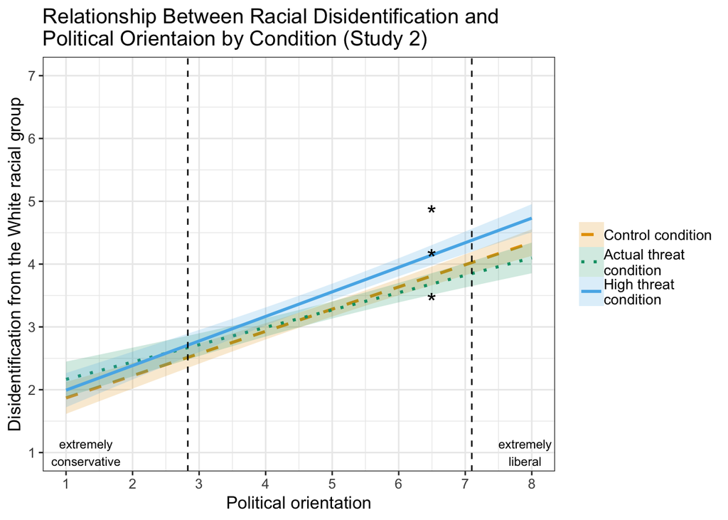

## Implications of Racial Disidentification for Racial Equity

Note: b1a3 = Index of moderated mediation, (a1b1+b1a3 -1) and (a1b1+b1a3 1) = conditional indirect effects

Moderated Mediation with DV as Individual Action

| lhs | op | rhs | label | est | se | z | pvalue | ci.lower | ci.upper | std.lv | std.all | std.nox |
| --- | --- | --- | --- | --- | --- | --- | --- | --- | --- | --- | --- | --- |
| WhtDis_comp_centered | ~1 |  |  | -0.0070961 | 0.0483941 | -0.1466319 | 0.8834226 | -0.1003889 | 0.0877560 | -0.0070961 | -0.0052509 | -0.0052509 |
| WhtDis_comp_centered | ~ | LibCon_centered | a1 | 0.3337183 | 0.0234276 | 14.2446528 | 0.0000000 | 0.2869869 | 0.3782952 | 0.3337183 | 0.5326330 | 0.2469429 |
| WhtDis_comp_centered | ~ | condition_contrast | a2 | 0.1399432 | 0.0486428 | 2.8769555 | 0.0040153 | 0.0446450 | 0.2337030 | 0.1399432 | 0.1035931 | 0.1035544 |
| WhtDis_comp_centered | ~ | LibCon_condition | a3 | 0.0575075 | 0.0232188 | 2.4767690 | 0.0132578 | 0.0107472 | 0.1022682 | 0.0575075 | 0.0917443 | 0.0425541 |
| IndivAction | ~ | WhtDis_comp_centered | b1 | 0.1726012 | 0.0440467 | 3.9185967 | 0.0000891 | 0.0827782 | 0.2589878 | 0.1726012 | 0.1752770 | 0.1752770 |
| IndivAction | ~1 |  |  | 4.7157473 | 0.0493325 | 95.5911043 | 0.0000000 | 4.6161870 | 4.8095182 | 4.7157473 | 3.5436280 | 3.5436280 |
| IndivAction | ~ | LibCon_centered | cp | 0.2420290 | 0.0273134 | 8.8611961 | 0.0000000 | 0.1850673 | 0.2929282 | 0.2420290 | 0.3922804 | 0.1818717 |
| WhtDis_comp_centered | ~~ | WhtDis_comp_centered |  | 1.2553757 | 0.0759475 | 16.5295212 | 0.0000000 | 1.1234734 | 1.4199844 | 1.2553757 | 0.6873956 | 0.6873956 |
| IndivAction | ~~ | IndivAction |  | 1.3120616 | 0.0854790 | 15.3495163 | 0.0000000 | 1.1529701 | 1.4901024 | 1.3120616 | 0.7408826 | 0.7408826 |
| LibCon_centered | ~~ | LibCon_centered |  | 4.6522505 | 0.0000000 | NA | NA | 4.6522505 | 4.6522505 | 4.6522505 | 1.0000000 | 4.6522505 |
| LibCon_centered | ~~ | condition_contrast |  | 0.0646793 | 0.0000000 | NA | NA | 0.0646793 | 0.0646793 | 0.0646793 | 0.0299758 | 0.0646793 |
| LibCon_centered | ~~ | LibCon_condition |  | 0.3093044 | 0.0000000 | NA | NA | 0.3093044 | 0.3093044 | 0.3093044 | 0.0665146 | 0.3093044 |
| condition_contrast | ~~ | condition_contrast |  | 1.0007473 | 0.0000000 | NA | NA | 1.0007473 | 1.0007473 | 1.0007473 | 1.0000000 | 1.0007473 |
| condition_contrast | ~~ | LibCon_condition |  | -0.0057424 | 0.0000000 | NA | NA | -0.0057424 | -0.0057424 | -0.0057424 | -0.0026625 | -0.0057424 |
| LibCon_condition | ~~ | LibCon_condition |  | 4.6481032 | 0.0000000 | NA | NA | 4.6481032 | 4.6481032 | 4.6481032 | 1.0000000 | 4.6481032 |
| LibCon_centered | ~1 |  |  | -0.0036152 | 0.0000000 | NA | NA | -0.0036152 | -0.0036152 | -0.0036152 | -0.0016761 | -0.0036152 |
| condition_contrast | ~1 |  |  | 0.0328467 | 0.0000000 | NA | NA | 0.0328467 | 0.0328467 | 0.0328467 | 0.0328344 | 0.0328467 |
| LibCon_condition | ~1 |  |  | 0.0644425 | 0.0000000 | NA | NA | 0.0644425 | 0.0644425 | 0.0644425 | 0.0298906 | 0.0644425 |
| b1a3 | := | b1*a3 | b1a3 | 0.0099259 | 0.0043645 | 2.2742216 | 0.0229527 | 0.0027444 | 0.0202824 | 0.0099259 | 0.0160807 | 0.0074587 |
| actualss | := | a1+a3*-1 | actualss | 0.2762108 | 0.0352554 | 7.8345768 | 0.0000000 | 0.2065825 | 0.3457086 | 0.2762108 | 0.4408888 | 0.2043888 |
| highss | := | a1+a3*1 | highss | 0.3912258 | 0.0304869 | 12.8325830 | 0.0000000 | 0.3293976 | 0.4497384 | 0.3912258 | 0.6243773 | 0.2894970 |
| actual | := | a1*b1+b1a3*-1 | actual | 0.0476743 | 0.0150995 | 3.1573420 | 0.0015921 | 0.0215735 | 0.0810047 | 0.0476743 | 0.0772776 | 0.0358247 |
| high | := | a1*b1+b1a3*1 | high | 0.0675260 | 0.0179450 | 3.7629510 | 0.0001679 | 0.0332601 | 0.1033137 | 0.0675260 | 0.1094390 | 0.0507421 |

Moderated Mediation with DV as Policy Support

| lhs | op | rhs | label | est | se | z | pvalue | ci.lower | ci.upper | std.lv | std.all | std.nox |
| --- | --- | --- | --- | --- | --- | --- | --- | --- | --- | --- | --- | --- |
| WhtDis_comp_centered | ~1 |  |  | -0.0070962 | 0.0483941 | -0.1466332 | 0.8834215 | -0.1003889 | 0.0877561 | -0.0070962 | -0.0052510 | -0.0052510 |
| WhtDis_comp_centered | ~ | LibCon_centered | a1 | 0.3337183 | 0.0234276 | 14.2446527 | 0.0000000 | 0.2869869 | 0.3782952 | 0.3337183 | 0.5326330 | 0.2469429 |
| WhtDis_comp_centered | ~ | condition_contrast | a2 | 0.1399433 | 0.0486428 | 2.8769556 | 0.0040153 | 0.0446450 | 0.2337029 | 0.1399433 | 0.1035931 | 0.1035544 |
| WhtDis_comp_centered | ~ | LibCon_condition | a3 | 0.0575075 | 0.0232188 | 2.4767695 | 0.0132577 | 0.0107472 | 0.1022682 | 0.0575075 | 0.0917443 | 0.0425541 |
| PolicySupport | ~ | WhtDis_comp_centered | b1 | 0.3279706 | 0.0514609 | 6.3731980 | 0.0000000 | 0.2258842 | 0.4259786 | 0.3279706 | 0.2649943 | 0.2649943 |
| PolicySupport | ~1 |  |  | 4.1605486 | 0.0533411 | 77.9988801 | 0.0000000 | 4.0539387 | 4.2612861 | 4.1605486 | 2.4875322 | 2.4875322 |
| PolicySupport | ~ | LibCon_centered | cp | 0.3898050 | 0.0334867 | 11.6405934 | 0.0000000 | 0.3248459 | 0.4550443 | 0.3898050 | 0.5026863 | 0.2330588 |
| WhtDis_comp_centered | ~~ | WhtDis_comp_centered |  | 1.2553757 | 0.0759475 | 16.5295215 | 0.0000000 | 1.1234734 | 1.4199844 | 1.2553757 | 0.6873956 | 0.6873956 |
| PolicySupport | ~~ | PolicySupport |  | 1.4902863 | 0.1036015 | 14.3847904 | 0.0000000 | 1.3051621 | 1.7125095 | 1.4902863 | 0.5327285 | 0.5327285 |
| LibCon_centered | ~~ | LibCon_centered |  | 4.6522505 | 0.0000000 | NA | NA | 4.6522505 | 4.6522505 | 4.6522505 | 1.0000000 | 4.6522505 |
| LibCon_centered | ~~ | condition_contrast |  | 0.0646793 | 0.0000000 | NA | NA | 0.0646793 | 0.0646793 | 0.0646793 | 0.0299758 | 0.0646793 |
| LibCon_centered | ~~ | LibCon_condition |  | 0.3093044 | 0.0000000 | NA | NA | 0.3093044 | 0.3093044 | 0.3093044 | 0.0665146 | 0.3093044 |
| condition_contrast | ~~ | condition_contrast |  | 1.0007473 | 0.0000000 | NA | NA | 1.0007473 | 1.0007473 | 1.0007473 | 1.0000000 | 1.0007473 |
| condition_contrast | ~~ | LibCon_condition |  | -0.0057424 | 0.0000000 | NA | NA | -0.0057424 | -0.0057424 | -0.0057424 | -0.0026625 | -0.0057424 |
| LibCon_condition | ~~ | LibCon_condition |  | 4.6481032 | 0.0000000 | NA | NA | 4.6481032 | 4.6481032 | 4.6481032 | 1.0000000 | 4.6481032 |
| LibCon_centered | ~1 |  |  | -0.0036152 | 0.0000000 | NA | NA | -0.0036152 | -0.0036152 | -0.0036152 | -0.0016761 | -0.0036152 |
| condition_contrast | ~1 |  |  | 0.0328467 | 0.0000000 | NA | NA | 0.0328467 | 0.0328467 | 0.0328467 | 0.0328344 | 0.0328467 |
| LibCon_condition | ~1 |  |  | 0.0644425 | 0.0000000 | NA | NA | 0.0644425 | 0.0644425 | 0.0644425 | 0.0298906 | 0.0644425 |
| b1a3 | := | b1*a3 | b1a3 | 0.0188608 | 0.0077761 | 2.4254859 | 0.0152879 | 0.0044301 | 0.0352632 | 0.0188608 | 0.0243117 | 0.0112766 |
| actualss | := | a1+a3*-1 | actualss | 0.2762108 | 0.0352554 | 7.8345765 | 0.0000000 | 0.2065825 | 0.3457087 | 0.2762108 | 0.4408888 | 0.2043888 |
| highss | := | a1+a3*1 | highss | 0.3912258 | 0.0304869 | 12.8325829 | 0.0000000 | 0.3293976 | 0.4497384 | 0.3912258 | 0.6243773 | 0.2894970 |
| actual | := | a1*b1+b1a3*-1 | actual | 0.0905890 | 0.0203247 | 4.4570812 | 0.0000083 | 0.0557188 | 0.1349872 | 0.0905890 | 0.1168330 | 0.0541619 |
| high | := | a1*b1+b1a3*1 | high | 0.1283106 | 0.0223914 | 5.7303601 | 0.0000000 | 0.0877035 | 0.1746495 | 0.1283106 | 0.1654564 | 0.0767150 |